# Tugas 1 — Pengantar Analisis Data Kategori

Latihan Analisis Data dengan R dan Quarto

Mahasiswa

Gay Faustine

NIM

241061014

Kode Tugas

ADK1-07018232

**Tujuan tugas.** Gunakan kembali konsep dan fungsi R yang telah dibahas pada Pertemuan 1 untuk mengenali struktur data kategori, membuat ringkasan deskriptif, memvisualisasikan data, dan menjelaskan insight secara hati-hati.

**CatatanPola kerja**

Ikuti pola kelas: **predict → run → inspect → explain**.

Pada setiap bagian diberikan **sedikit petunjuk kode**.  
Jika diminta menjelaskan atau menuliskan interpretasi, gunakan kotak **Jawaban Anda** yang telah disediakan.

# 1 1. Mengenali Data

Gunakan R untuk melihat beberapa baris awal, struktur data, dan nama variabel.

**TipPetunjuk kode**

```r
head(...)
str(...)
names(...)
```

Ganti `...` dengan objek data yang digunakan.

```r
head(data)
```

```
  RecordID     ProgramStudi Gender DeviceUtama ModaBelajar    Kepuasan
1   950728 Sistem Informasi      L  Smartphone        Buku Sangat Puas
2   917000   Sains Aktuaria      L  Smartphone     Diskusi        <NA>
3   251566   Sains Aktuaria      P      Tablet     Praktik        Puas
4   963895   Sains Aktuaria      L      Tablet        Buku       Cukup
5   710698       Sains Data      L      Laptop       Video        Puas
6   813061   Sains Aktuaria      L  Smartphone       Video        Puas
  IntensitasBelajar DurasiBelajarJam       PaketID
1            Rendah              2.6 ADK1-07018232
2            Tinggi              9.6 ADK1-07018232
3            Sedang              5.0 ADK1-07018232
4            Tinggi             13.8 ADK1-07018232
5            Sedang              5.6 ADK1-07018232
6            Sedang              3.6 ADK1-07018232
```

```r
str(data)
```

```
'data.frame':   93 obs. of  9 variables:
 $ RecordID         : int  950728 917000 251566 963895 710698 813061 153880 719277 904904 857137 ...
 $ ProgramStudi     : chr  "Sistem Informasi" "Sains Aktuaria" "Sains Aktuaria" "Sains Aktuaria" ...
 $ Gender           : chr  "L" "L" "P" "L" ...
 $ DeviceUtama      : chr  "Smartphone" "Smartphone" "Tablet" "Tablet" ...
 $ ModaBelajar      : chr  "Buku" "Diskusi" "Praktik" "Buku" ...
 $ Kepuasan         : chr  "Sangat Puas" NA "Puas" "Cukup" ...
 $ IntensitasBelajar: chr  "Rendah" "Tinggi" "Sedang" "Tinggi" ...
 $ DurasiBelajarJam : num  2.6 9.6 5 13.8 5.6 3.6 4.7 8.2 9.1 10.1 ...
 $ PaketID          : chr  "ADK1-07018232" "ADK1-07018232" "ADK1-07018232" "ADK1-07018232" ...
```

```r
names(data)
```

```
[1] "RecordID"          "ProgramStudi"      "Gender"
[4] "DeviceUtama"       "ModaBelajar"       "Kepuasan"
[7] "IntensitasBelajar" "DurasiBelajarJam"  "PaketID"
```

Lengkapi tabel berikut.

| Variabel | Jenis Variabel | Alasan Singkat |
| --- | --- | --- |
| RecordID | Identifier | Nilai unik untuk setiap responden, tidak punya makna kuantitatif |
| ProgramStudi | Nominal | Kategori tanpa urutan (Sistem Informasi, Sains Aktuaria, dll) |
| Gender | Nominal | Kategori tanpa urutan (L/P) |
| DeviceUtama | Nominal | Kategori tanpa urutan (Smartphone, Tablet, Laptop) |
| ModaBelajar | Nominal | Kategori tanpa urutan (Buku, Diskusi, Praktik, Video) |
| Kepuasan | Ordinal | Punya urutan tingkat (Tidak Puas < Cukup < Puas < Sangat Puas) |
| IntensitasBelajar | Ordinal | Punya urutan tingkat (Rendah < Sedang < Tinggi) |
| DurasiBelajarJam | Numerik (rasio) | Angka kontinu yang bisa dihitung dan dibandingkan besarnya |

Jawab singkat:

1. Variabel mana yang merupakan identifier?
2. Variabel mana yang bersifat ordinal?
3. Mengapa kode angka belum tentu berarti data numerik?

**Jawaban Anda**

1. Variabel identifier adalah RecordID, karena nilainya unik untuk setiap baris dan hanya berfungsi sebagai penanda, bukan untuk dianalisis nilainya.
2. Variabel yang bersifat ordinal adalah Kepuasan dan IntensitasBelajar, karena kategorinya memiliki urutan tingkat yang bermakna.
3. Kode angka belum tentu berarti data numerik karena angka tersebut bisa saja hanya melambangkan kategori (misalnya kode 1 untuk “Laki-laki” dan 2 untuk “Perempuan”), sehingga tidak masuk akal untuk dijumlahkan atau dirata-ratakan secara matematis.

# 2 2. Menyiapkan Data Kategori

Variabel latihan Anda:

```r
cat("Nominal :", identitas$nominal_utama[1], "\n")
```

```
Nominal : Gender
```

```r
cat("Ordinal :", identitas$ordinal_utama[1], "\n")
```

```
Ordinal : Kepuasan
```

```r
cat("Urutan  :", identitas$urutan_ordinal[1], "\n")
```

```
Urutan  : Tidak Puas|Cukup|Puas|Sangat Puas
```

Lakukan hal berikut:

1. ubah variabel nominal menjadi factor;
2. ubah variabel ordinal menjadi ordered factor;
3. periksa level kategorinya.

**TipPetunjuk kode**

Untuk nominal:

```r
factor(...)
levels(...)
```

Untuk ordinal:

```r
factor(..., levels = ..., ordered = TRUE)
```

```r
nominal_var <- identitas$nominal_utama[1]
ordinal_var <- identitas$ordinal_utama[1]
urutan <- strsplit(identitas$urutan_ordinal[1], "\\|")[[1]]

data[[nominal_var]] <- factor(data[[nominal_var]])
data[[ordinal_var]] <- factor(data[[ordinal_var]], levels = urutan, ordered = TRUE)

levels(data[[nominal_var]])
```

```
[1] "L" "P"
```

```r
levels(data[[ordinal_var]])
```

```
[1] "Tidak Puas"  "Cukup"       "Puas"        "Sangat Puas"
```

Tuliskan satu kalimat: **mengapa urutan level ordinal perlu ditetapkan dengan benar?**

**Jawaban Anda**

Urutan level ordinal perlu ditetapkan dengan benar agar R dapat membandingkan kategori sesuai tingkatannya yang sebenarnya (misalnya “Puas” lebih tinggi dari “Cukup”), sehingga analisis dan visualisasi yang melibatkan urutan tidak menghasilkan kesimpulan yang keliru.

# 3 3. Quality Control Awal

Lakukan pemeriksaan sederhana terhadap:

- struktur data;
- level/kategori;
- missing value;
- konsistensi penulisan kategori.

**TipPetunjuk kode**

Beberapa pola fungsi yang dapat digunakan:

```r
str(...)
levels(...)
unique(...)
is.na(...)
colSums(...)
```

Pilih fungsi yang sesuai dengan tujuan pemeriksaan Anda.

```r
str(data)
```

```
'data.frame':   93 obs. of  9 variables:
 $ RecordID         : int  950728 917000 251566 963895 710698 813061 153880 719277 904904 857137 ...
 $ ProgramStudi     : chr  "Sistem Informasi" "Sains Aktuaria" "Sains Aktuaria" "Sains Aktuaria" ...
 $ Gender           : Factor w/ 2 levels "L","P": 1 1 2 1 1 1 1 2 1 1 ...
 $ DeviceUtama      : chr  "Smartphone" "Smartphone" "Tablet" "Tablet" ...
 $ ModaBelajar      : chr  "Buku" "Diskusi" "Praktik" "Buku" ...
 $ Kepuasan         : Ord.factor w/ 4 levels "Tidak Puas"<"Cukup"<..: 4 NA 3 2 3 3 3 2 2 3 ...
 $ IntensitasBelajar: chr  "Rendah" "Tinggi" "Sedang" "Tinggi" ...
 $ DurasiBelajarJam : num  2.6 9.6 5 13.8 5.6 3.6 4.7 8.2 9.1 10.1 ...
 $ PaketID          : chr  "ADK1-07018232" "ADK1-07018232" "ADK1-07018232" "ADK1-07018232" ...
```

```r
levels(data[[nominal_var]])
```

```
[1] "L" "P"
```

```r
levels(data[[ordinal_var]])
```

```
[1] "Tidak Puas"  "Cukup"       "Puas"        "Sangat Puas"
```

```r
colSums(is.na(data))
```

```
         RecordID      ProgramStudi            Gender       DeviceUtama
                0                 0                 0                 0
      ModaBelajar          Kepuasan IntensitasBelajar  DurasiBelajarJam
                1                 1                 0                 1
          PaketID
                0
```

```r
sapply(data, function(col) if (is.character(col)) unique(col) else NULL)
```

```
$RecordID
NULL

$ProgramStudi
[1] "Sistem Informasi" "Sains Aktuaria"   "Sains Data"       "Matematika"

$Gender
NULL

$DeviceUtama
[1] "Smartphone" "Tablet"     "Laptop"

$ModaBelajar
[1] "Buku"    "Diskusi" "Praktik" "Video"   NA

$Kepuasan
NULL

$IntensitasBelajar
[1] "Rendah" "Tinggi" "Sedang"

$DurasiBelajarJam
NULL

$PaketID
[1] "ADK1-07018232"
```

Tuliskan **dua temuan singkat** dari pemeriksaan tersebut.

**Jawaban Anda**

1. Terdapat missing value pada tiga variabel: ModaBelajar, Kepuasan, dan DurasiBelajarJam, masing-masing sebanyak 1 data yang hilang.
2. Kategori pada variabel ProgramStudi, DeviceUtama, dan IntensitasBelajar sudah konsisten penulisannya (tidak ada variasi ejaan atau kapitalisasi yang berbeda untuk kategori yang sama).

# 4 4. Frekuensi dan Proporsi

Sebelum menjalankan kode, prediksi:

> Menurut Anda, kategori mana yang paling banyak muncul pada variabel nominal Anda?

**Prediksi Anda**

Berdasarkan pengamatan awal, diperkirakan kategori Gender akan cukup seimbang antara Laki-laki dan Perempuan.

Setelah itu, buat:

- tabel frekuensi untuk variabel nominal;
- proporsi untuk variabel ordinal.

**TipPetunjuk kode**

```r
table(...)
prop.table(...)
```

Anda dapat menyimpan hasil `table()` ke sebuah objek terlebih dahulu sebelum menghitung proporsi.

```r
freq_nominal <- table(data[[nominal_var]])
freq_nominal
```

```
 L  P
46 47
```

```r
tab_ordinal <- table(data[[ordinal_var]])
prop_ordinal <- prop.table(tab_ordinal)
prop_ordinal
```

```
 Tidak Puas       Cukup        Puas Sangat Puas
  0.1086957   0.2391304   0.3913043   0.2608696
```

Tuliskan **dua kalimat insight** berdasarkan output.

**Interpretasi Anda**

1. Distribusi Gender cukup seimbang, dengan 46 responden Laki-laki (49,5%) dan 47 responden Perempuan (50,5%).
2. Pada variabel Kepuasan, mayoritas responden berada pada kategori “Puas” (39,1%), diikuti “Sangat Puas” (26,1%), sementara hanya 10,9% yang merasa “Tidak Puas”.

# 5 5. Tabel Silang

Pasangan variabel Anda:

```r
x <- identitas$tab_baris[1]
y <- identitas$tab_kolom[1]

cat("Baris :", x, "\n")
```

```
Baris : DeviceUtama
```

```r
cat("Kolom :", y, "\n")
```

```
Kolom : Kepuasan
```

Buat tabel silang untuk kedua variabel tersebut.

Jika diperlukan, tampilkan proporsi per baris untuk membantu membaca pola.

**TipPetunjuk kode**

```r
table(..., ...)
prop.table(..., margin = 1)
```

Lengkapi sendiri objek yang diperlukan.

```r
tab_silang <- table(data[[x]], data[[y]])
tab_silang
```

```
             Tidak Puas Cukup Puas Sangat Puas
  Laptop              2     6   14          14
  Smartphone          4     6   15           7
  Tablet              4    10    7           3
```

```r
prop.table(tab_silang, margin = 1)
```

```
             Tidak Puas      Cukup       Puas Sangat Puas
  Laptop     0.05555556 0.16666667 0.38888889  0.38888889
  Smartphone 0.12500000 0.18750000 0.46875000  0.21875000
  Tablet     0.16666667 0.41666667 0.29166667  0.12500000
```

Tuliskan **satu kalimat** yang menjelaskan pola yang tampak.

**Interpretasi Anda**

Proporsi kepuasan “Sangat Puas” tertinggi tampak pada pengguna Laptop (38,9%), sementara pengguna Tablet memiliki proporsi “Tidak Puas” dan “Cukup” yang lebih tinggi dibanding dua perangkat lainnya (16,7% dan 41,7%).

**Penting**

Gunakan bahasa deskriptif. Jangan langsung menyimpulkan adanya hubungan signifikan atau sebab-akibat.

# 6 6. Visualisasi Kategorik

Variabel yang divisualisasikan:

```r
v <- identitas$visualisasi[1]
cat("Variabel grafik :", v, "\n")
```

```
Variabel grafik : Gender
```

Buat **satu grafik batang** seperti yang telah dipelajari pada Pertemuan 1.

**TipPetunjuk kode**

```r
library(ggplot2)

ggplot(..., aes(x = ...)) +
  geom_bar() +
  labs(...)
```

Sesuaikan objek data, variabel, judul, dan label sumbu.

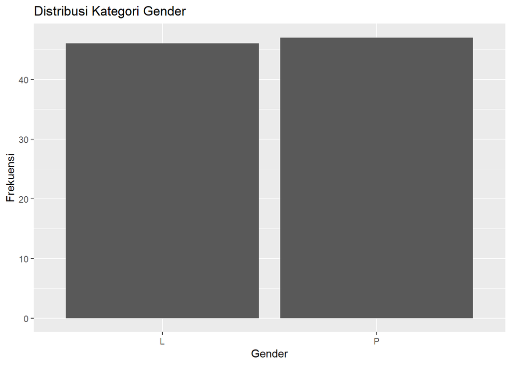

```r
library(ggplot2)

ggplot(data, aes(x = .data[[v]])) +
  geom_bar() +
  labs(
    title = paste("Distribusi Kategori", v),
    x = v,
    y = "Frekuensi"
  )
```

Tuliskan **satu kalimat** interpretasi grafik.

**Interpretasi Anda**

Grafik batang menunjukkan jumlah responden Perempuan (47) sedikit lebih banyak dibanding Laki-laki (46), meskipun perbedaannya sangat kecil sehingga distribusi Gender pada data ini dapat dikatakan hampir merata.

# 7 7. Kesimpulan

Tuliskan **3 poin kesimpulan singkat** berdasarkan hasil analisis.

Setiap kesimpulan harus:

- didukung oleh output yang telah Anda hasilkan;
- menggunakan angka yang relevan;
- ditulis dengan bahasa Anda sendiri;
- tidak menggunakan klaim sebab-akibat.

**Kesimpulan Anda**

1. Distribusi Gender pada data ini hampir seimbang, dengan 46 responden Laki-laki dan 47 responden Perempuan.
2. Tingkat kepuasan responden secara umum cenderung positif, dengan 65,2% responden berada pada kategori “Puas” atau “Sangat Puas”.
3. Pola penggunaan device menunjukkan variasi tingkat kepuasan yang berbeda, di mana pengguna Laptop memiliki proporsi “Sangat Puas” tertinggi (38,9%) dibanding pengguna Smartphone (21,9%) dan Tablet (12,5%).

**Analisis Data Kategori — Tugas 1**  
Predict → Run → Inspect → Explain